# SF Salaries

Important note:

all analysis here was based on the analysis of SF Salaries data set from users msjgriffiths and JustinDomingue

# Loading of packages and libraries required

# Read File

```r
salary_data1 <- read.csv("../SF salaries/salaries.csv",
                         na=c("Not Provided"))
```

# About the Dataset

One way to understand how a city government works is by looking at who it employs and how its employees are compensated. This data contains the names, job title, and compensation for San Francisco city employees on an annual basis from 2011 to 2014.

# Checking the structure of data

```r
str(salary_data1)
```

```
## 'data.frame':    148654 obs. of  13 variables:
##  $ Id              : int  1 2 3 4 5 6 7 8 9 10 ...
##  $ EmployeeName    : Factor w/ 110810 levels "A Bernard  Fatooh",..: 77635 34712 1560 17232 81101 23164 3271 22709 73975 47938 ...
##  $ JobTitle        : Factor w/ 2159 levels "Account Clerk",..: 836 298 298 2149 594 135 246 609 246 370 ...
##  $ BasePay         : num  167411 155966 212739 77916 134402 ...
##  $ OvertimePay     : num  0 245132 106088 56121 9737 ...
##  $ OtherPay        : num  400184 137811 16453 198307 182235 ...
##  $ Benefits        : num  NA NA NA NA NA NA NA NA NA NA ...
##  $ TotalPay        : num  567595 538909 335280 332344 326373 ...
##  $ TotalPayBenefits: num  567595 538909 335280 332344 326373 ...
##  $ Year            : int  2011 2011 2011 2011 2011 2011 2011 2011 2011 2011 ...
##  $ Notes           : logi  NA NA NA NA NA NA ...
##  $ Agency          : Factor w/ 1 level "San Francisco": 1 1 1 1 1 1 1 1 1 1 ...
##  $ Status          : Factor w/ 3 levels "","FT","PT": 1 1 1 1 1 1 1 1 1 1 ...
```

```r
summary(salary_data1)
```

```
##        Id               EmployeeName
##  Min.   :     1   Kevin Lee   :    13
##  1st Qu.: 37164   Richard Lee :    11
##  Median : 74328   Steven Lee  :    11
##  Mean   : 74328   William Wong:    11
##  3rd Qu.:111491   John Chan   :     9
##  Max.   :148654   (Other)     :148597
##                   NA's        :     2
##                          JobTitle         BasePay
##  Transit Operator            :  7036   Min.   :  -166
##  Special Nurse               :  4389   1st Qu.: 33588
##  Registered Nurse            :  3736   Median : 65007
##  Public Svc Aide-Public Works:  2518   Mean   : 66325
##  Police Officer 3            :  2421   3rd Qu.: 94691
##  Custodian                   :  2418   Max.   :319275
##  (Other)                     :126136   NA's   :609
##   OvertimePay           OtherPay           Benefits
##  Min.   :    -0.01   Min.   : -7058.6   Min.   :  -33.89
##  1st Qu.:     0.00   1st Qu.:     0.0   1st Qu.:11535.40
##  Median :     0.00   Median :   811.3   Median :28628.62
##  Mean   :  5066.06   Mean   :  3648.8   Mean   :25007.89
##  3rd Qu.:  4658.18   3rd Qu.:  4236.1   3rd Qu.:35566.86
##  Max.   :245131.88   Max.   :400184.2   Max.   :96570.66
##  NA's   :4           NA's   :4          NA's   :36163
##     TotalPay        TotalPayBenefits        Year       Notes
##  Min.   :  -618.1   Min.   :  -618.1   Min.   :2011   Mode:logical
##  1st Qu.: 36169.0   1st Qu.: 44065.7   1st Qu.:2012   NA's:148654
##  Median : 71426.6   Median : 92404.1   Median :2013
##  Mean   : 74768.3   Mean   : 93692.6   Mean   :2013
##  3rd Qu.:105839.1   3rd Qu.:132876.5   3rd Qu.:2014
##  Max.   :567595.4   Max.   :567595.4   Max.   :2014
##
##            Agency       Status
##  San Francisco:148654     :110535
##                         FT: 22334
##                         PT: 15785
##
##
##
##
```

```r
describe(salary_data1)
```

```
## salary_data1
##
##  13  Variables      148654  Observations
## ---------------------------------------------------------------------------
## Id
##        n  missing distinct     Info     Mean      Gmd      .05      .10
##   148654        0   148654        1    74328    49552     7434    14866
##      .25      .50      .75      .90      .95
##    37164    74328   111491   133789   141221
##
## lowest :      1      2      3      4      5
## highest: 148650 148651 148652 148653 148654
## ---------------------------------------------------------------------------
## EmployeeName
##        n  missing distinct
##   148652        2   110810
##
## lowest : A Bernard  Fatooh     A Bernard Fatooh      A BERNARD FATOOH      A ELIZABETH MARCHASIN A JAMIL NIAZI
## highest: Zuna T Luu            ZUREN MEI             Zuri  Jones           Zuri Jones            ZURI JONES
## ---------------------------------------------------------------------------
## JobTitle
##        n  missing distinct
##   148654        0     2159
##
## lowest : Account Clerk                                  ACCOUNT CLERK                                  ACCOUNTANT                                     Accountant I                                   Accountant II
## highest: X-Ray Laboratory Aide                          X-RAY LABORATORY AIDE                          Youth Comm Advisor                             YOUTH COMMISSION ADVISOR, BOARD OF SUPERVISORS ZOO CURATOR
## ---------------------------------------------------------------------------
## BasePay
##        n  missing distinct     Info     Mean      Gmd      .05      .10
##   148045      609   109489        1    66325    48171     2478     6988
##      .25      .50      .75      .90      .95
##    33588    65007    94691   121036   136223
##
## lowest :   -166.01   -121.63   -109.22   -106.60   -101.88
## highest: 313312.52 313686.01 315572.01 318835.49 319275.01
## ---------------------------------------------------------------------------
## OvertimePay
##        n  missing distinct     Info     Mean      Gmd      .05      .10
##   148650        4    65998    0.859     5066     8274        0        0
##      .25      .50      .75      .90      .95
```

[output cut: 49 more lines]

```
##             n       missing      distinct         value
##        148654             0             1 San Francisco
##
## San Francisco (148654, 1)
## ---------------------------------------------------------------------------
## Status
##        n  missing distinct
##   148654        0        3
##
## (110535, 0.744), FT (22334, 0.150), PT (15785, 0.106)
## ---------------------------------------------------------------------------
##
## Variables with all observations missing:
##
## [1] Notes
```

```r
head(salary_data1)
```

```
##   Id      EmployeeName                                       JobTitle
## 1  1    NATHANIEL FORD GENERAL MANAGER-METROPOLITAN TRANSIT AUTHORITY
## 2  2      GARY JIMENEZ                CAPTAIN III (POLICE DEPARTMENT)
## 3  3    ALBERT PARDINI                CAPTAIN III (POLICE DEPARTMENT)
## 4  4 CHRISTOPHER CHONG           WIRE ROPE CABLE MAINTENANCE MECHANIC
## 5  5   PATRICK GARDNER   DEPUTY CHIEF OF DEPARTMENT,(FIRE DEPARTMENT)
## 6  6    DAVID SULLIVAN                      ASSISTANT DEPUTY CHIEF II
##    BasePay OvertimePay OtherPay Benefits TotalPay TotalPayBenefits Year
## 1 167411.2        0.00 400184.2       NA 567595.4         567595.4 2011
## 2 155966.0   245131.88 137811.4       NA 538909.3         538909.3 2011
## 3 212739.1   106088.18  16452.6       NA 335279.9         335279.9 2011
## 4  77916.0    56120.71 198306.9       NA 332343.6         332343.6 2011
## 5 134401.6     9737.00 182234.6       NA 326373.2         326373.2 2011
## 6 118602.0     8601.00 189082.7       NA 316285.7         316285.7 2011
##   Notes        Agency Status
## 1    NA San Francisco
## 2    NA San Francisco
## 3    NA San Francisco
## 4    NA San Francisco
## 5    NA San Francisco
## 6    NA San Francisco
```

```r
tail(salary_data1)
```

```
##            Id  EmployeeName                   JobTitle BasePay OvertimePay
## 148649 148649   Leon Walker                  Custodian       0           0
## 148650 148650 Roy I Tillery                  Custodian       0           0
## 148651 148651  Not provided               Not provided      NA          NA
## 148652 148652  Not provided               Not provided      NA          NA
## 148653 148653  Not provided               Not provided      NA          NA
## 148654 148654     Joe Lopez Counselor, Log Cabin Ranch       0           0
##        OtherPay Benefits TotalPay TotalPayBenefits Year Notes
## 148649     0.00        0     0.00             0.00 2014    NA
## 148650     0.00        0     0.00             0.00 2014    NA
## 148651       NA       NA     0.00             0.00 2014    NA
## 148652       NA       NA     0.00             0.00 2014    NA
## 148653       NA       NA     0.00             0.00 2014    NA
## 148654  -618.13        0  -618.13          -618.13 2014    NA
##               Agency Status
## 148649 San Francisco     PT
## 148650 San Francisco     PT
## 148651 San Francisco
## 148652 San Francisco
## 148653 San Francisco
## 148654 San Francisco     PT
```

```r
glimpse(salary_data1)
```

```
## Observations: 148,654
## Variables: 13
## $ Id               <int> 1, 2, 3, 4, 5, 6, 7, 8, 9, 10, 11, 12, 13, 14...
## $ EmployeeName     <fctr> NATHANIEL FORD, GARY JIMENEZ, ALBERT PARDINI...
## $ JobTitle         <fctr> GENERAL MANAGER-METROPOLITAN TRANSIT AUTHORI...
## $ BasePay          <dbl> 167411.18, 155966.02, 212739.13, 77916.00, 13...
## $ OvertimePay      <dbl> 0.00, 245131.88, 106088.18, 56120.71, 9737.00...
## $ OtherPay         <dbl> 400184.25, 137811.38, 16452.60, 198306.90, 18...
## $ Benefits         <dbl> NA, NA, NA, NA, NA, NA, NA, NA, NA, NA, NA, N...
## $ TotalPay         <dbl> 567595.4, 538909.3, 335279.9, 332343.6, 32637...
## $ TotalPayBenefits <dbl> 567595.4, 538909.3, 335279.9, 332343.6, 32637...
## $ Year             <int> 2011, 2011, 2011, 2011, 2011, 2011, 2011, 201...
## $ Notes            <lgl> NA, NA, NA, NA, NA, NA, NA, NA, NA, NA, NA, N...
## $ Agency           <fctr> San Francisco, San Francisco, San Francisco,...
## $ Status           <fctr> , , , , , , , , , , , , , , , , , , , , , , ...
```

# Cleaning the data

In our dataset there are 3 columns that we are not needed for our analysis, and therefore will be removed. These columns are: id, Agency and Notes

```r
table(duplicated(salary_data1$Id))
```

```
##
##  FALSE
## 148654
```

```r
salary_data1 <- salary_data1 %>%
  select(-Id, -Agency, -Notes)
```

# Getting a glimpse at some metrics of our data

```r
salary1BPmean <- mean(as.numeric(salary_data1$BasePay), na.rm = TRUE)
salary1BPmedian <- median(as.numeric(salary_data1$BasePay), na.rm = TRUE)
salary1OTPmean <- mean(as.numeric(salary_data1$OvertimePay), na.rm = TRUE)
salary1OTPmedian <- median(as.numeric(salary_data1$OvertimePay), na.rm = TRUE)
salary1Benmean <- mean(as.numeric(salary_data1$Benefits), na.rm = TRUE)
salary1Benmedian <- median(as.numeric(salary_data1$Benefits), na.rm = TRUE)
salary1TPmean <-  mean(as.numeric(salary_data1$TotalPay), na.rm = TRUE)
salary1TPmedian <- median(as.numeric(salary_data1$TotalPay), na.rm = TRUE)
salary1TPBmean <- mean(as.numeric(salary_data1$TotalPayBenefits), na.rm = TRUE)
salary1TPBmedian <- median(as.numeric(salary_data1$TotalPayBenefits), na.rm = TRUE)
```

After we got some basic numbers of our data we split the dataset into 4 smaller datasets according to the year.

```r
salary2011 <- salary_data1[which(salary_data1$Year==2011), ]
salary2012 <- salary_data1[which(salary_data1$Year==2012), ]
salary2013 <- salary_data1[which(salary_data1$Year==2013), ]
salary2014 <- salary_data1[which(salary_data1$Year==2014), ]
```

Now we can compare each years key values to the values we got from the whole dataset to see if there is any significant change over the course of four years between 2011 and 2014.

Again we are going to get the mean and median of our sample, only this time it will be specific for each year.

For 2011:

```r
salary2011BPmean <- mean(as.numeric(salary2011$BasePay), na.rm = TRUE)
salary2011BPmedian <- median(as.numeric(salary2011$BasePay), na.rm = TRUE)
salary2011OTPmean <- mean(as.numeric(salary2011$OvertimePay), na.rm = TRUE)
salary2011OTPmedian <- median(as.numeric(salary2011$OvertimePay), na.rm = TRUE)
salary2011Benmean <- mean(as.numeric(salary2011$Benefits), na.rm = TRUE)
salary2011Benmedian <- median(as.numeric(salary2011$Benefits), na.rm = TRUE)
salary2011TPmean <-  mean(as.numeric(salary2011$TotalPay), na.rm = TRUE)
salary2011TPmedian <- median(as.numeric(salary2011$TotalPay), na.rm = TRUE)
salary2011TPBmean <- mean(as.numeric(salary2011$TotalPayBenefits), na.rm = TRUE)
salary2011TPBmedian <- median(as.numeric(salary2011$TotalPayBenefits), na.rm = TRUE)
```

For 2012:

```r
salary2012BPmean <- mean(as.numeric(salary2012$BasePay), na.rm = TRUE)
salary2012BPmedian <- median(as.numeric(salary2012$BasePay), na.rm = TRUE)
salary2012OTPmean <- mean(as.numeric(salary2012$OvertimePay), na.rm = TRUE)
salary2012OTPmedian <- median(as.numeric(salary2012$OvertimePay), na.rm = TRUE)
salary2012Benmean <- mean(as.numeric(salary2012$Benefits), na.rm = TRUE)
salary2012Benmedian <- median(as.numeric(salary2012$Benefits), na.rm = TRUE)
salary2012TPmean <-  mean(as.numeric(salary2012$TotalPay), na.rm = TRUE)
salary2012TPmedian <- median(as.numeric(salary2012$TotalPay), na.rm = TRUE)
salary2012TPBmean <- mean(as.numeric(salary2012$TotalPayBenefits), na.rm = TRUE)
salary2012TPBmedian <- median(as.numeric(salary2012$TotalPayBenefits), na.rm = TRUE)
```

For 2013:

```r
salary2013BPmean <- mean(as.numeric(salary2013$BasePay), na.rm = TRUE)
salary2013BPmedian <- median(as.numeric(salary2013$BasePay), na.rm = TRUE)
salary2013OTPmean <- mean(as.numeric(salary2013$OvertimePay), na.rm = TRUE)
salary2013OTPmedian <- median(as.numeric(salary2013$OvertimePay), na.rm = TRUE)
salary2013Benmean <- mean(as.numeric(salary2013$Benefits), na.rm = TRUE)
salary2013Benmedian <- median(as.numeric(salary2013$Benefits), na.rm = TRUE)
salary2013TPmean <-  mean(as.numeric(salary2013$TotalPay), na.rm = TRUE)
salary2013TPmedian <- median(as.numeric(salary2013$TotalPay), na.rm = TRUE)
salary2013TPBmean <- mean(as.numeric(salary2013$TotalPayBenefits), na.rm = TRUE)
salary2013TPBmedian <- median(as.numeric(salary2013$TotalPayBenefits), na.rm = TRUE)
```

For 2014:

```r
salary2014BPmean <- mean(as.numeric(salary2014$BasePay), na.rm = TRUE)
salary2014BPmedian <- median(as.numeric(salary2014$BasePay), na.rm = TRUE)
salary2014OTPmean <- mean(as.numeric(salary2014$OvertimePay), na.rm = TRUE)
salary2014OTPmedian <- median(as.numeric(salary2014$OvertimePay), na.rm = TRUE)
salary2014Benmean <- mean(as.numeric(salary2014$Benefits), na.rm = TRUE)
salary2014Benmedian <- median(as.numeric(salary2014$Benefits), na.rm = TRUE)
salary2014TPmean <-  mean(as.numeric(salary2014$TotalPay), na.rm = TRUE)
salary2014TPmedian <- median(as.numeric(salary2014$TotalPay), na.rm = TRUE)
salary2014TPBmean <- mean(as.numeric(salary2014$TotalPayBenefits), na.rm = TRUE)
salary2014TPBmedian <- median(as.numeric(salary2014$TotalPayBenefits), na.rm = TRUE)
```

And some plots of these metrics:

- BasePay Mean plot per year.

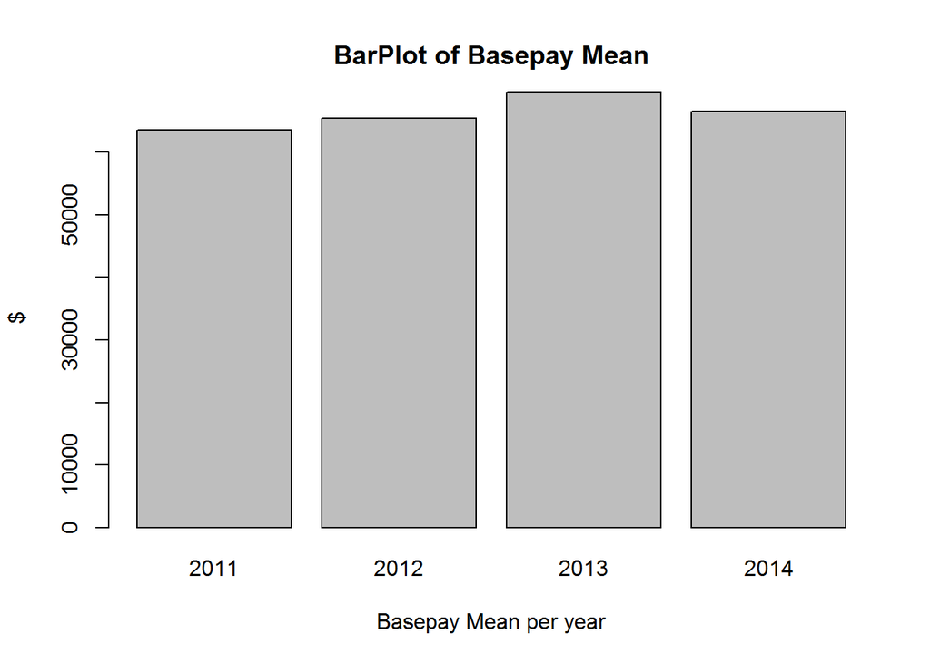

```r
plotBPmean <- c(salary2011BPmean, salary2012BPmean, salary2013BPmean, salary2014BPmean)
barplot(plotBPmean, xlab = "Basepay Mean per year", ylab = "$" , main = "BarPlot of Basepay Mean",
        ylim = c(0, 67000), names.arg = c("2011" , "2012" , "2013", "2014"))
```

- Overtime Mean plot per year.

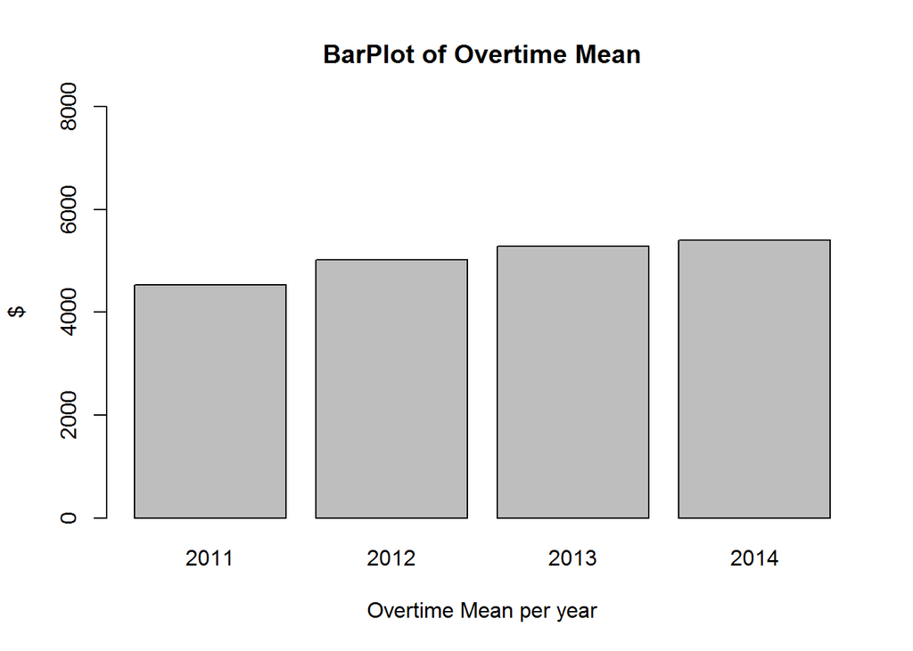

```r
plotOTPmean <- c(salary2011OTPmean, salary2012OTPmean , salary2013OTPmean , salary2014OTPmean)
barplot(plotOTPmean, xlab = "Overtime Mean per year", ylab = "$" , main = "BarPlot of Overtime Mean",
        ylim = c(0, 8000), names.arg = c("2011" , "2012" , "2013", "2014"))
```

* Plot of salary distribution over years.

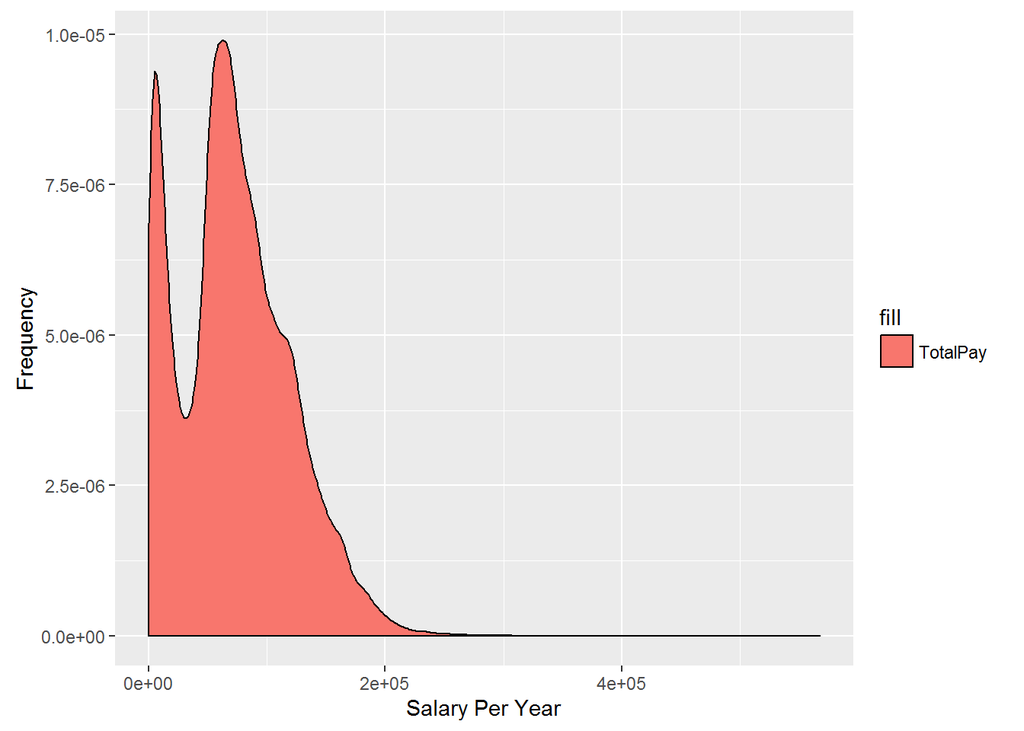

```r
qplot(salary2011$TotalPay, geom="density" , fill = "TotalPay" , xlab = "Salary Per Year" , ylab = "Frequency")
```

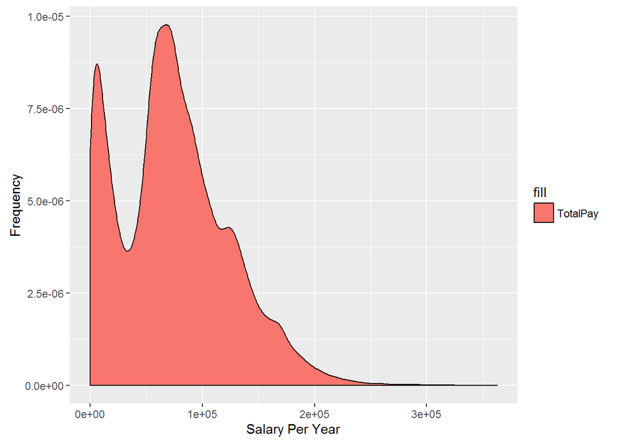

```r
qplot(salary2012$TotalPay, geom="density" , fill = "TotalPay" , xlab = "Salary Per Year" , ylab = "Frequency")
```

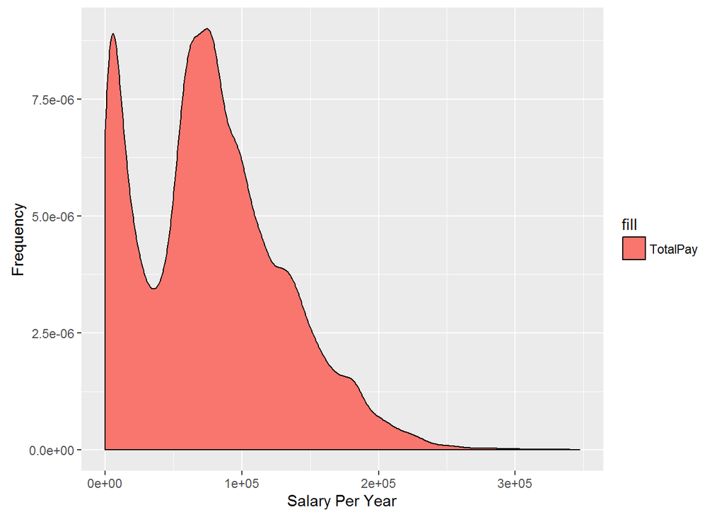

```r
qplot(salary2013$TotalPay, geom="density" , fill = "TotalPay" , xlab = "Salary Per Year" , ylab = "Frequency")
```

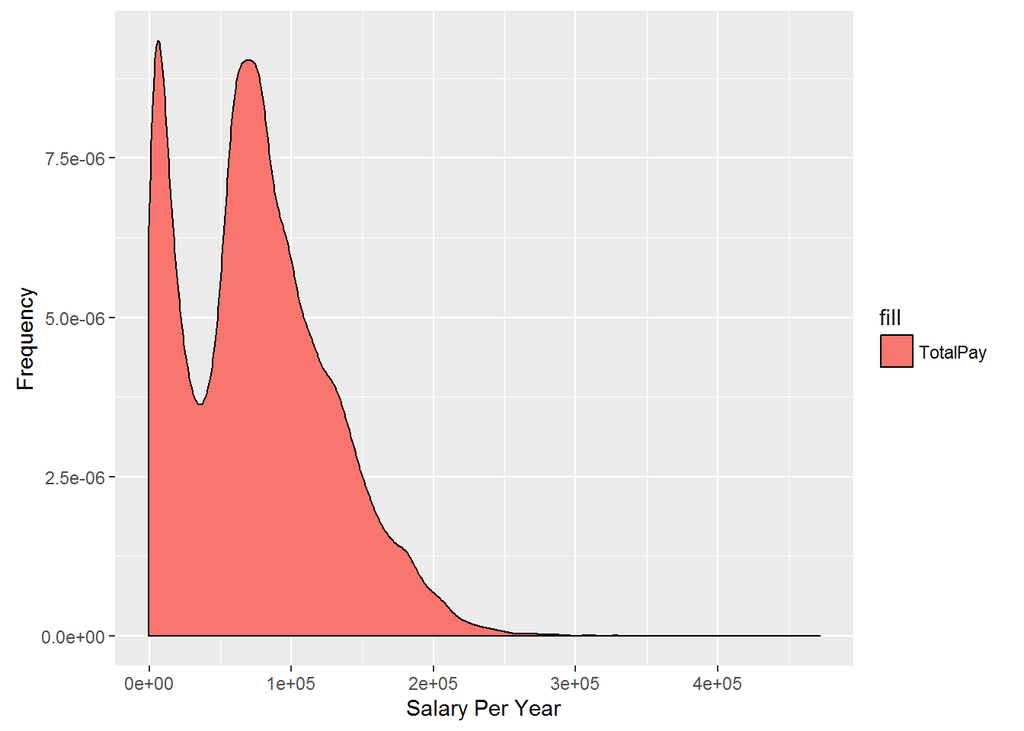

```r
qplot(salary2014$TotalPay, geom="density" , fill = "TotalPay" , xlab = "Salary Per Year" , ylab = "Frequency")
```

## other useful metrics

- 10 Most Frequent job titles for all our sample

```r
salary_data1 %>%
  group_by(JobTitle) %>%
  summarise(Frequency = n()) %>%
  arrange(desc(Frequency)) %>%
  head( salary_data1 , n = 10)
```

```
## # A tibble: 10 × 2
##                        JobTitle Frequency
##                          <fctr>     <int>
## 1              Transit Operator      7036
## 2                 Special Nurse      4389
## 3              Registered Nurse      3736
## 4  Public Svc Aide-Public Works      2518
## 5              Police Officer 3      2421
## 6                     Custodian      2418
## 7              TRANSIT OPERATOR      2388
## 8                   Firefighter      2359
## 9             Recreation Leader      1971
## 10       Patient Care Assistant      1945
```

- for 2011

```r
salary2011 %>%
  group_by(JobTitle) %>%
  summarise(Frequency = n()) %>%
  arrange(desc(Frequency)) %>%
  head( salary_data1 , n = 10)
```

```
## # A tibble: 10 × 2
##                                JobTitle Frequency
##                                  <fctr>     <int>
## 1                      TRANSIT OPERATOR      2388
## 2                         SPECIAL NURSE      1402
## 3                      REGISTERED NURSE      1219
## 4                             CUSTODIAN       796
## 5                           FIREFIGHTER       794
## 6                    POLICE OFFICER III       779
## 7                     RECREATION LEADER       692
## 8                        DEPUTY SHERIFF       685
## 9   MENTAL HEALTH REHABILITATION WORKER       559
## 10 PUBLIC SERVICE AIDE-SPECIAL PROGRAMS       531
```

- for 2012

```r
salary2012 %>%
  group_by(JobTitle) %>%
  summarise(Frequency = n()) %>%
  arrange(desc(Frequency)) %>%
  head( salary_data1 , n = 10)
```

```
## # A tibble: 10 × 2
##                        JobTitle Frequency
##                          <fctr>     <int>
## 1              Transit Operator      2262
## 2                 Special Nurse      1466
## 3              Registered Nurse      1271
## 4              Police Officer 3       864
## 5                     Custodian       825
## 6                   Firefighter       759
## 7  Public Svc Aide-Public Works       743
## 8                Deputy Sheriff       663
## 9             Recreation Leader       627
## 10       Patient Care Assistant       617
```

- for 2013

```r
salary2013 %>%
  group_by(JobTitle) %>%
  summarise(Frequency = n()) %>%
  arrange(desc(Frequency)) %>%
  head( salary_data1 , n = 10)
```

```
## # A tibble: 10 × 2
##                        JobTitle Frequency
##                          <fctr>     <int>
## 1              Transit Operator      2295
## 2                 Special Nurse      1445
## 3              Registered Nurse      1231
## 4  Public Svc Aide-Public Works       859
## 5                     Custodian       789
## 6                   Firefighter       785
## 7              Police Officer 3       774
## 8        Patient Care Assistant       676
## 9             Recreation Leader       654
## 10               Deputy Sheriff       653
```

- for 2014

```r
salary2014 %>%
  group_by(JobTitle) %>%
  summarise(Frequency = n()) %>%
  arrange(desc(Frequency)) %>%
  head( salary_data1 , n = 10)
```

```
## # A tibble: 10 × 2
##                        JobTitle Frequency
##                          <fctr>     <int>
## 1              Transit Operator      2479
## 2                 Special Nurse      1478
## 3              Registered Nurse      1234
## 4  Public Svc Aide-Public Works       916
## 5                   Firefighter       815
## 6                     Custodian       804
## 7              Police Officer 3       783
## 8             Recreation Leader       690
## 9        Patient Care Assistant       652
## 10               Deputy Sheriff       617
```

## Jobs that occur only once per year

- For 2011

```r
salary2011 %>%
  group_by(JobTitle) %>%
  summarise(Frequency = n()) %>%
  mutate(OccursOnce = Frequency == 1) %>%
  group_by(OccursOnce) %>%
  summarise(Total = n())
```

```
## # A tibble: 2 × 2
##   OccursOnce Total
##        <lgl> <int>
## 1      FALSE   845
## 2       TRUE   200
```

- For 2012

```r
salary2012 %>%
  group_by(JobTitle) %>%
  summarise(Frequency = n()) %>%
  mutate(OccursOnce = Frequency == 1) %>%
  group_by(OccursOnce) %>%
  summarise(Total = n())
```

```
## # A tibble: 2 × 2
##   OccursOnce Total
##        <lgl> <int>
## 1      FALSE   854
## 2       TRUE   190
```

- For 2013

```r
salary2013 %>%
  group_by(JobTitle) %>%
  summarise(Frequency = n()) %>%
  mutate(OccursOnce = Frequency == 1) %>%
  group_by(OccursOnce) %>%
  summarise(Total = n())
```

```
## # A tibble: 2 × 2
##   OccursOnce Total
##        <lgl> <int>
## 1      FALSE   849
## 2       TRUE   202
```

- For 2014

```r
salary2014 %>%
  group_by(JobTitle) %>%
  summarise(Frequency = n()) %>%
  mutate(OccursOnce = Frequency == 1) %>%
  group_by(OccursOnce) %>%
  summarise(Total = n())
```

```
## # A tibble: 2 × 2
##   OccursOnce Total
##        <lgl> <int>
## 1      FALSE   822
## 2       TRUE   175
```

## Some pay analysis

How many have a Total pay of 0?

- For 2011

```r
salary2011  %>%
  filter(TotalPay <= 0)
```

```
##         EmployeeName                                   JobTitle BasePay
## 1     PAULETTE ADAMS STATIONARY ENGINEER, WATER TREATMENT PLANT       0
## 2      KAUKAB MOHSIN                           TRANSIT OPERATOR       0
## 3 JOSEPHINE MCCREARY                                 MANAGER IV       0
##   OvertimePay OtherPay Benefits TotalPay TotalPayBenefits Year Status
## 1           0        0       NA        0                0 2011
## 2           0        0       NA        0                0 2011
## 3           0        0       NA        0                0 2011
```

3 people in 2011

- For 2012

```r
salary2012  %>%
  filter(TotalPay <= 0)
```

```
##          EmployeeName                     JobTitle BasePay OvertimePay
## 1       Roland Baylon        Deputy Court Clerk II       0           0
## 2    Felecia Phillips             Registered Nurse       0           0
## 3     Robert Giannini                      Painter       0           0
## 4          Nelly Kuan    Senior Eligibility Worker       0           0
## 5     William Mathews    Transit Power Line Worker       0           0
## 6       Gayle Mathews   Senior Collections Officer       0           0
## 7        Linda Carter          Transit Car Cleaner       0           0
## 8       Hui Qin Zhang                        Clerk       0           0
## 9     Georgina Pineda             Transit Operator       0           0
## 10 Millicent Williams             Transit Operator       0           0
## 11        Richard Lee             Transit Operator       0           0
## 12       Audrey Sylve             Transit Operator       0           0
## 13   Kimberly Johnson             Transit Operator       0           0
## 14     Teddy Querubin             Transit Operator       0           0
```

[output cut: 37 more lines]

25 people in 2012

- For 2013

```r
salary2013  %>%
  filter(TotalPay <=0)
```

```
##                    EmployeeName                       JobTitle BasePay
## 1                Eugene G Duffy           Sewer Service Worker      NA
## 2                  Randy J Keys                      Carpenter      NA
## 3             Dominic C Marquez                    Sign Worker      NA
## 4          Lennard B Hutchinson                    Electrician      NA
## 5                Paulet  Gaines                  Account Clerk      NA
## 6             Rosario D Medrano      Senior Eligibility Worker      NA
## 7          Samantha J Blanchard                       Gardener      NA
## 8               Andre M Johnson    Communications Dispatcher 1      NA
## 9              Gloria M Jackson               Home Health Aide      NA
## 10                  Vao N Davis         Transit Fare Inspector      NA
## 11          Edith L Stone-Walsh      Traffic Survey Technician      NA
## 12                 Nelly R Kuan      Senior Eligibility Worker      NA
## 13  Patrice I Booker-Williamson            Senior Clerk Typist      NA
## 14                Ramon A Useda        Parking Control Officer      NA
```

[output cut: 563 more lines]

288 people in 2013

- For 2014

```r
salary2014  %>%
  filter(TotalPay <= 0)
```

```
##              EmployeeName                       JobTitle BasePay
## 1       Timothy C Benetti           Special Assistant 15       0
## 2           Ginger D Huey Community Police Services Aide       0
## 3           Mark D Dunlop     BdComm Mbr, Grp3,M=$50/Mtg       0
## 4      Linda F Richardson     BdComm Mbr, Grp3,M=$50/Mtg       0
## 5         Kendra Armitage                       Gardener       0
## 6          Derrick K Chan                       Engineer       0
## 7       Rodel G Dela Cruz               Transit Operator       0
## 8          Rachel L Souki                  Special Nurse       0
## 9        Karen E Sadberry       Deputy Probation Officer       0
## 10               Kai Chen               Transit Operator       0
## 11    Lawrence E Thompson                 Deputy Sheriff       0
## 12      Claudia Valentino                    Firefighter       0
## 13          Emily K Riggs            Health Care Analyst       0
## 14         Maribeth Riday                  Special Nurse       0
```

[output cut: 93 more lines]

53 people in 2014

How many have 0 total pay but receive benefits per year?

*For 2011

```r
salary2011  %>%
  filter(TotalPay <= 0 & TotalPayBenefits > 0)
```

```
##  [1] EmployeeName     JobTitle         BasePay          OvertimePay
##  [5] OtherPay         Benefits         TotalPay         TotalPayBenefits
##  [9] Year             Status
## <0 rows> (or 0-length row.names)
```

Noone in 2011

- For 2012

```r
salary2012  %>%
  filter(TotalPay <= 0 & TotalPayBenefits > 0)
```

```
##          EmployeeName                     JobTitle BasePay OvertimePay
## 1       Roland Baylon        Deputy Court Clerk II       0           0
## 2    Felecia Phillips             Registered Nurse       0           0
## 3     Robert Giannini                      Painter       0           0
## 4          Nelly Kuan    Senior Eligibility Worker       0           0
## 5     William Mathews    Transit Power Line Worker       0           0
## 6       Gayle Mathews   Senior Collections Officer       0           0
## 7        Linda Carter          Transit Car Cleaner       0           0
## 8       Hui Qin Zhang                        Clerk       0           0
## 9     Georgina Pineda             Transit Operator       0           0
## 10 Millicent Williams             Transit Operator       0           0
## 11        Richard Lee             Transit Operator       0           0
## 12       Audrey Sylve             Transit Operator       0           0
## 13   Kimberly Johnson             Transit Operator       0           0
## 14     Teddy Querubin             Transit Operator       0           0
```

[output cut: 37 more lines]

25 people in 2012

- For 2013

```r
salary2013  %>%
  filter(TotalPay <= 0 & TotalPayBenefits > 0)
```

```
##                    EmployeeName                       JobTitle BasePay
## 1                Eugene G Duffy           Sewer Service Worker      NA
## 2                  Randy J Keys                      Carpenter      NA
## 3             Dominic C Marquez                    Sign Worker      NA
## 4          Lennard B Hutchinson                    Electrician      NA
## 5                Paulet  Gaines                  Account Clerk      NA
## 6             Rosario D Medrano      Senior Eligibility Worker      NA
## 7          Samantha J Blanchard                       Gardener      NA
## 8               Andre M Johnson    Communications Dispatcher 1      NA
## 9              Gloria M Jackson               Home Health Aide      NA
## 10                  Vao N Davis         Transit Fare Inspector      NA
## 11          Edith L Stone-Walsh      Traffic Survey Technician      NA
## 12                 Nelly R Kuan      Senior Eligibility Worker      NA
## 13  Patrice I Booker-Williamson            Senior Clerk Typist      NA
## 14                Ramon A Useda        Parking Control Officer      NA
```

[output cut: 557 more lines]

285 people in 2013

- For 2014

```r
salary2014  %>%
  filter(TotalPay <= 0 & TotalPayBenefits > 0)
```

```
##            EmployeeName                       JobTitle BasePay OvertimePay
## 1     Timothy C Benetti           Special Assistant 15       0           0
## 2         Ginger D Huey Community Police Services Aide       0           0
## 3         Mark D Dunlop     BdComm Mbr, Grp3,M=$50/Mtg       0           0
## 4    Linda F Richardson     BdComm Mbr, Grp3,M=$50/Mtg       0           0
## 5       Kendra Armitage                       Gardener       0           0
## 6        Derrick K Chan                       Engineer       0           0
## 7     Rodel G Dela Cruz               Transit Operator       0           0
## 8        Rachel L Souki                  Special Nurse       0           0
## 9      Karen E Sadberry       Deputy Probation Officer       0           0
## 10             Kai Chen               Transit Operator       0           0
## 11  Lawrence E Thompson                 Deputy Sheriff       0           0
## 12    Claudia Valentino                    Firefighter       0           0
## 13        Emily K Riggs            Health Care Analyst       0           0
## 14       Maribeth Riday                  Special Nurse       0           0
```

[output cut: 37 more lines]

25 people in 2014

how many have no pay and no benefits per year?

- For 2011

```r
salary2011  %>%
  filter(TotalPay <= 0 & TotalPayBenefits == 0)
```

```
##         EmployeeName                                   JobTitle BasePay
## 1     PAULETTE ADAMS STATIONARY ENGINEER, WATER TREATMENT PLANT       0
## 2      KAUKAB MOHSIN                           TRANSIT OPERATOR       0
## 3 JOSEPHINE MCCREARY                                 MANAGER IV       0
##   OvertimePay OtherPay Benefits TotalPay TotalPayBenefits Year Status
## 1           0        0       NA        0                0 2011
## 2           0        0       NA        0                0 2011
## 3           0        0       NA        0                0 2011
```

3 people in 2011

- For 2012

```r
salary2012  %>%
  filter(TotalPay <= 0 & TotalPayBenefits == 0)
```

```
##  [1] EmployeeName     JobTitle         BasePay          OvertimePay
##  [5] OtherPay         Benefits         TotalPay         TotalPayBenefits
##  [9] Year             Status
## <0 rows> (or 0-length row.names)
```

Noone in 2012

- For 2013

```r
salary2013  %>%
  filter(TotalPay <= 0 & TotalPayBenefits == 0)
```

```
##  [1] EmployeeName     JobTitle         BasePay          OvertimePay
##  [5] OtherPay         Benefits         TotalPay         TotalPayBenefits
##  [9] Year             Status
## <0 rows> (or 0-length row.names)
```

Noone in 2013

- For 2014

```r
salary2014  %>%
  filter(TotalPay <= 0 & TotalPayBenefits == 0)
```

```
##              EmployeeName                     JobTitle BasePay OvertimePay
## 1           Paulet Gaines                Account Clerk       0           0
## 2        Brett A Lundberg              General Laborer       0           0
## 3          Mark W Mcclure              General Laborer       0           0
## 4       Elizabeth Iniguez           Transcriber Typist       0           0
## 5            Randy J Keys                    Carpenter       0           0
## 6         Andre M Johnson  Communications Dispatcher 1       0           0
## 7  Sharon D Owens-Webster   Protective Services Worker       0           0
## 8        Edward Ferdinand              General Laborer       0           0
## 9          David M Turner          Transit Car Cleaner       0           0
## 10    James S Kibblewhite              General Laborer       0           0
## 11          Andrew J Enzi          Arborist Technician       0           0
## 12       Kadeshra D Green       Transit Fare Inspector       0           0
## 13   Lennard B Hutchinson                  Electrician       0           0
## 14      Richard A Talbert                    Custodian       0           0
```

[output cut: 41 more lines]

27 in 2014

# Counting the number of people that belong to different salary groups making them percentage and making a pie chart per year

- 2011

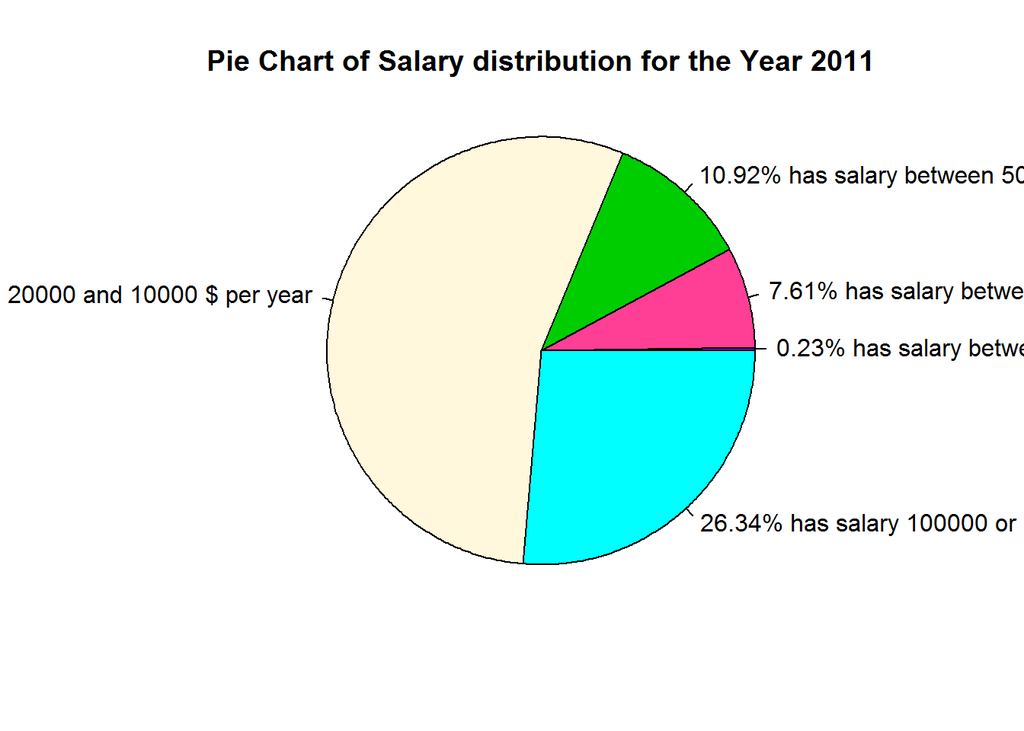

```r
piechart20111 <- count(salary2011[which(salary2011$TotalPay > 0 & salary2011$TotalPay < 100), ])/36159 * 100
piechart20112 <- count(salary2011[which(salary2011$TotalPay > 100 & salary2011$TotalPay < 5000), ])/36159 * 100
piechart20113 <- count(salary2011[which(salary2011$TotalPay > 5000 & salary2011$TotalPay < 20000), ])/36159 * 100
piechart20114 <- count(salary2011[which(salary2011$TotalPay > 20000 & salary2011$TotalPay < 100000), ])/36159 * 100
piechart20115 <- count(salary2011[which(salary2011$TotalPay > 100000), ])/36159 * 100
piechart2011 <- as.numeric(c(piechart20111 , piechart20112 , piechart20113 , piechart20114 , piechart20115))
pie(piechart2011, labels = c("0.23% has salary between 0 and 100 $ per year", "7.61% has salary between 100 and 500 $ per year",
                             "10.92% has salary between 5000 and 20000 $ per year" ,
                             "54.87% has salary between 20000 and 10000 $ per year"
                             , "26.34% has salary 100000 or above $ per year"),  edges = 500, radius = 1 ,
                             col = c("purple", "violetred1", "green3","cornsilk", "cyan"),
                             main = "Pie Chart of Salary distribution for the Year 2011")
```

- 2012

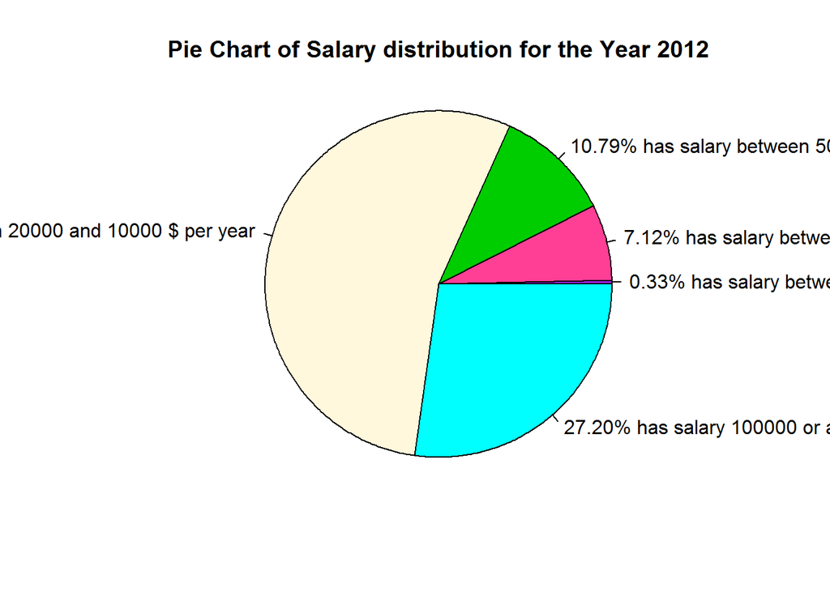

```r
piechart20121 <- count(salary2012[which(salary2012$TotalPay > 0 & salary2012$TotalPay < 100), ])/36766 * 100
piechart20122 <- count(salary2012[which(salary2012$TotalPay > 100 & salary2012$TotalPay < 5000), ])/36766 * 100
piechart20123 <- count(salary2012[which(salary2012$TotalPay > 5000 & salary2012$TotalPay < 20000), ])/36766 * 100
piechart20124 <- count(salary2012[which(salary2012$TotalPay > 20000 & salary2012$TotalPay < 100000), ])/36766 * 100
piechart20125 <- count(salary2012[which(salary2012$TotalPay > 100000), ])/36766 * 100
piechart2012 <- as.numeric(c(piechart20121 , piechart20122 , piechart20123 , piechart20124 , piechart20125))
pie(piechart2012, labels = c("0.33% has salary between 0 and 100 $ per year", "7.12% has salary between 100 and 500 $ per year",
                             "10.79% has salary between 5000 and 20000 $ per year" ,
                             "54.48% has salary between 20000 and 10000 $ per year"
                             , "27.20% has salary 100000 or above $ per year"),  edges = 500, radius = 1 ,
    col = c("purple", "violetred1", "green3","cornsilk", "cyan"),
    main = "Pie Chart of Salary distribution for the Year 2012")
```

- 2013

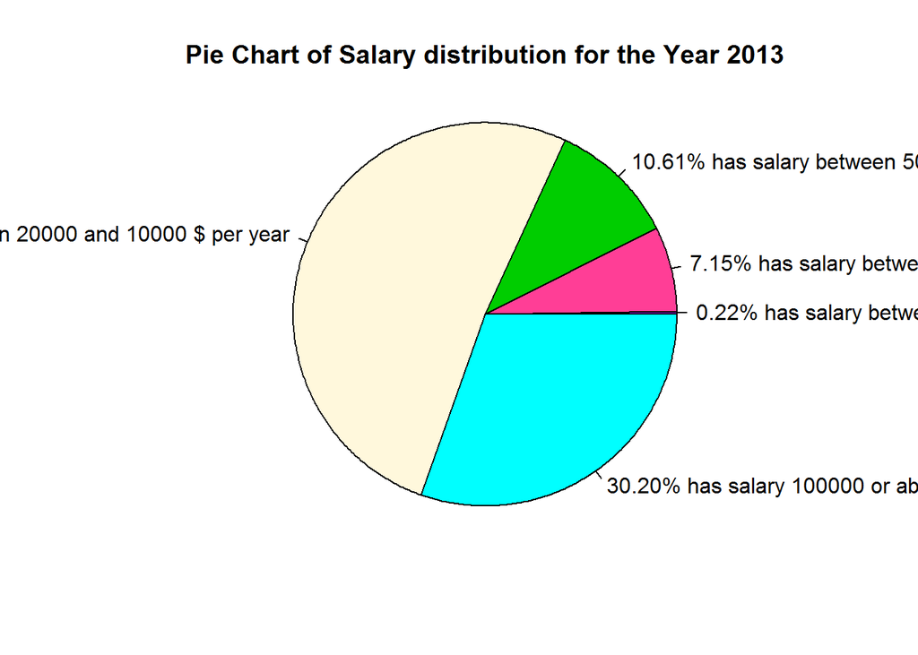

```r
piechart20131 <- count(salary2013[which(salary2013$TotalPay > 0 & salary2013$TotalPay < 100), ])/37606 * 100
piechart20132 <- count(salary2013[which(salary2013$TotalPay > 100 & salary2013$TotalPay < 5000), ])/37606 * 100
piechart20133 <- count(salary2013[which(salary2013$TotalPay > 5000 & salary2013$TotalPay < 20000), ])/37606 * 100
piechart20134 <- count(salary2013[which(salary2013$TotalPay > 20000 & salary2013$TotalPay < 100000), ])/37606 * 100
piechart20135 <- count(salary2013[which(salary2013$TotalPay > 100000), ])/37606 * 100
piechart2013 <- as.numeric(c(piechart20131 , piechart20132 , piechart20133 , piechart20134 , piechart20135))
pie(piechart2013, labels = c("0.22% has salary between 0 and 100 $ per year", "7.15% has salary between 100 and 500 $ per year",
                             "10.61% has salary between 5000 and 20000 $ per year" ,
                             "51.02% has salary between 20000 and 10000 $ per year"
                             , "30.20% has salary 100000 or above $ per year"),  edges = 500, radius = 1 ,
    col = c("purple", "violetred1", "green3","cornsilk", "cyan"),
    main = "Pie Chart of Salary distribution for the Year 2013")
```

- 2014

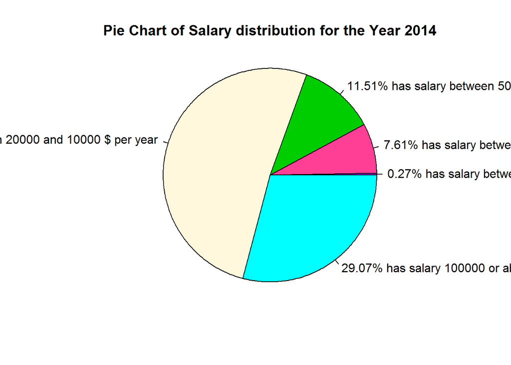

```r
piechart20141 <- count(salary2013[which(salary2014$TotalPay > 0 & salary2014$TotalPay < 100), ])/38123 * 100
piechart20142 <- count(salary2013[which(salary2014$TotalPay > 100 & salary2014$TotalPay < 5000), ])/38123 * 100
piechart20143 <- count(salary2013[which(salary2014$TotalPay > 5000 & salary2014$TotalPay < 20000), ])/38123 * 100
piechart20144 <- count(salary2013[which(salary2014$TotalPay > 20000 & salary2014$TotalPay < 100000), ])/38123 * 100
piechart20145 <- count(salary2013[which(salary2014$TotalPay > 100000), ])/38123 * 100
piechart2014 <- as.numeric(c(piechart20141 , piechart20142 , piechart20143 , piechart20144 , piechart20145))
pie(piechart2014, labels = c("0.27% has salary between 0 and 100 $ per year", "7.61% has salary between 100 and 500 $ per year",
                             "11.51% has salary between 5000 and 20000 $ per year" ,
                             "51.38% has salary between 20000 and 10000 $ per year"
                             , "29.07% has salary 100000 or above $ per year"),  edges = 500, radius = 1 ,
    col = c("purple", "violetred1", "green3","cornsilk", "cyan"),
    main = "Pie Chart of Salary distribution for the Year 2014")
```